# Model Interpretation

Bodo Winter

16/12/2019

## Preliminaries

Load packages:

```r
library(tidyverse)
library(brms)
library(sf) # for maps
library(rnaturalearth) # for maps
library(rnaturalearthdata) # for maps
library(ggrepel) # for unoverlapping labels on maps
library(gridExtra)
```

Load language data for plotting:

```r
lang_info <- read_csv('../data/language_info.csv')
field_info <- read_csv('../data/language_info_field.csv')
```

Load ggplot2 theme:

```r
source('theme_timo.R')
```

Load models:

```r
load('../models/main_mdl.RData')
load('../models/main_animacy_mdl.RData')
load('../models/field_animacy_mdl.RData')
load('../models/field_mdl.RData')
```

## Posterior predictive checks:

Perform posterior predictive checks:

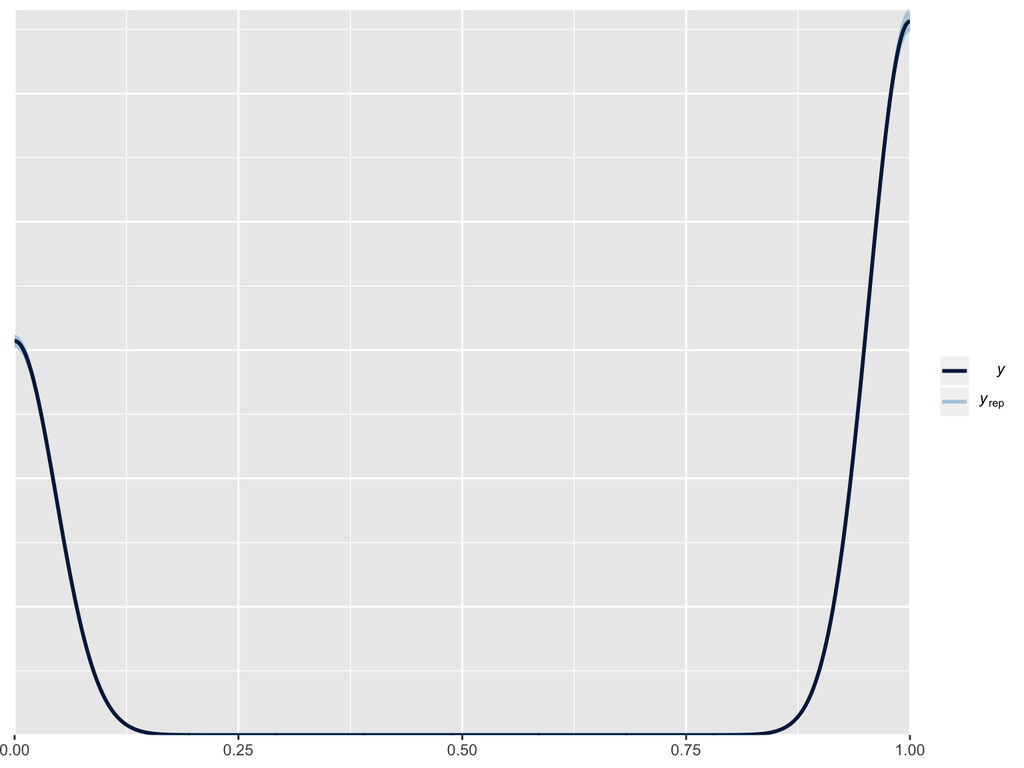

```r
pp_check(main_mdl, nsamples = 1000)
```

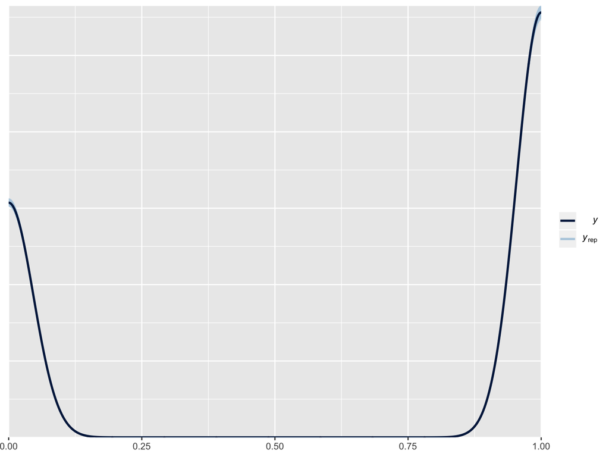

```r
pp_check(main_animacy_mdl, nsamples = 1000)
```

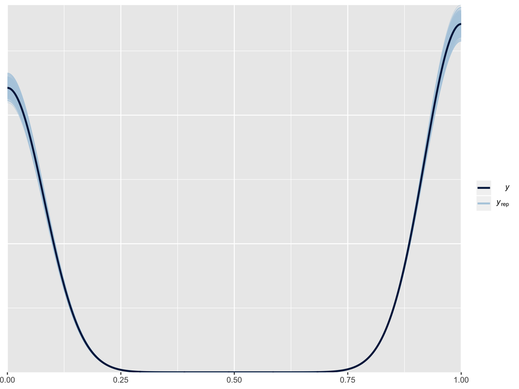

```r
pp_check(field_mdl, nsamples = 1000)
```

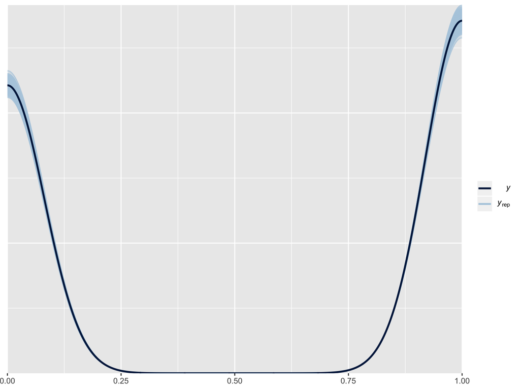

```r
pp_check(field_animacy_mdl, nsamples = 1000)
```

They all look pretty good! (The black line falls well within the rest of the lines)

## Summarize models, first accuracy-only, without consideration of animacy:

Summarize models, first the main model for the online data:

```r
summary(main_mdl)
```

```
##  Family: bernoulli
##   Links: mu = logit
## Formula: ACC ~ 1 + (1 | ID) + (1 | Meaning) + (1 | UniqueItem) + (1 | Team) + (1 | Language) + (1 | Genus)
##    Data: web (Number of observations: 70532)
## Samples: 4 chains, each with iter = 4000; warmup = 2000; thin = 1;
##          total post-warmup samples = 8000
##
## Group-Level Effects:
## ~Genus (Number of levels: 10)
##               Estimate Est.Error l-95% CI u-95% CI Eff.Sample Rhat
## sd(Intercept)     0.22      0.13     0.02     0.51       2181 1.00
##
## ~ID (Number of levels: 789)
##               Estimate Est.Error l-95% CI u-95% CI Eff.Sample Rhat
## sd(Intercept)     0.32      0.01     0.30     0.35       3691 1.00
##
## ~Language (Number of levels: 24)
##               Estimate Est.Error l-95% CI u-95% CI Eff.Sample Rhat
## sd(Intercept)     0.27      0.06     0.18     0.40       2717 1.00
##
## ~Meaning (Number of levels: 30)
##               Estimate Est.Error l-95% CI u-95% CI Eff.Sample Rhat
## sd(Intercept)     1.13      0.17     0.84     1.52       3020 1.00
##
## ~Team (Number of levels: 11)
##               Estimate Est.Error l-95% CI u-95% CI Eff.Sample Rhat
## sd(Intercept)     0.14      0.11     0.01     0.43       2317 1.00
##
## ~UniqueItem (Number of levels: 90)
##               Estimate Est.Error l-95% CI u-95% CI Eff.Sample Rhat
## sd(Intercept)     0.57      0.06     0.47     0.69       3339 1.00
##
## Population-Level Effects:
##           Estimate Est.Error l-95% CI u-95% CI Eff.Sample Rhat
## Intercept     0.65      0.25     0.15     1.12       2109 1.00
##
## Samples were drawn using sampling(NUTS). For each parameter, Eff.Sample
## is a crude measure of effective sample size, and Rhat is the potential
## scale reduction factor on split chains (at convergence, Rhat = 1).
```

What is the estimated average accuracy?

```r
plogis(fixef(main_mdl)[, 1])
```

```
## [1] 0.6562549
```

```r
# Lower bound of 95% CI:

plogis(fixef(main_mdl)[, 3])
```

```
## [1] 0.5376316
```

```r
# Upper bound of 95% CI:

plogis(fixef(main_mdl)[, 4])
```

```
## [1] 0.7547876
```

The lower threshold does not include chance level (= 1/6).

Extract posterior samples:

```r
main_samples <- posterior_samples(main_mdl)
field_samples <- posterior_samples(field_mdl)
```

What is the posterior probability of this being above the chancel threshold of 1/6?

```r
myposts <- main_samples$b_Intercept
sum(myposts > qlogis(1/6)) / length(myposts)
```

```
## [1] 1
```

100%, not a single posterior sample below the chance threshold of 1/6.

Check the same for the field data:

```r
summary(field_mdl)
```

```
##  Family: bernoulli
##   Links: mu = logit
## Formula: ACC ~ 1 + (1 | ID) + (1 | Meaning) + (1 | UniqueItem) + (1 | Team) + (1 | Language)
##    Data: field (Number of observations: 5143)
## Samples: 4 chains, each with iter = 4000; warmup = 2000; thin = 1;
##          total post-warmup samples = 8000
##
## Group-Level Effects:
## ~ID (Number of levels: 143)
##               Estimate Est.Error l-95% CI u-95% CI Eff.Sample Rhat
## sd(Intercept)     0.57      0.05     0.47     0.68       3747 1.00
##
## ~Language (Number of levels: 7)
##               Estimate Est.Error l-95% CI u-95% CI Eff.Sample Rhat
## sd(Intercept)     0.86      0.36     0.43     1.77       2588 1.00
##
## ~Meaning (Number of levels: 12)
##               Estimate Est.Error l-95% CI u-95% CI Eff.Sample Rhat
## sd(Intercept)     1.10      0.37     0.48     1.91       1556 1.01
##
## ~Team (Number of levels: 7)
##               Estimate Est.Error l-95% CI u-95% CI Eff.Sample Rhat
## sd(Intercept)     0.28      0.28     0.01     0.93       2307 1.00
##
## ~UniqueItem (Number of levels: 36)
##               Estimate Est.Error l-95% CI u-95% CI Eff.Sample Rhat
## sd(Intercept)     0.95      0.17     0.68     1.35       1478 1.00
##
## Population-Level Effects:
##           Estimate Est.Error l-95% CI u-95% CI Eff.Sample Rhat
## Intercept     0.09      0.56    -1.01     1.17       2407 1.00
##
## Samples were drawn using sampling(NUTS). For each parameter, Eff.Sample
## is a crude measure of effective sample size, and Rhat is the potential
## scale reduction factor on split chains (at convergence, Rhat = 1).
```

What is the estimated average accuracy?

```r
plogis(fixef(field_mdl)[, 1])
```

```
## [1] 0.5221542
```

```r
# Lower bound of 95% CI:

plogis(fixef(field_mdl)[, 3])
```

```
## [1] 0.2667585
```

```r
# Upper bound of 95% CI:

plogis(fixef(field_mdl)[, 4])
```

```
## [1] 0.7627485
```

The lower threshold does not include chance level (= 1/12).

What is the posterior probability of this being above the chancel threshold of 1/12?

```r
myposts <- field_samples$b_Intercept
sum(myposts > qlogis(1/12)) / length(myposts)
```

```
## [1] 0.99925
```

99%, very few posterior samples below the chance threshold of 1/12.

## Summarize models, with animacy predictors:

Then the one with the animacy predictor:

```r
summary(main_animacy_mdl)
```

```
##  Family: bernoulli
##   Links: mu = logit
## Formula: ACC ~ Animacy + (1 + Animacy | ID) + (1 | Meaning) + (1 | UniqueItem) + (1 | Team) + (1 + Animacy | Language) + (1 | Genus)
##    Data: web (Number of observations: 70532)
## Samples: 4 chains, each with iter = 4000; warmup = 2000; thin = 1;
##          total post-warmup samples = 8000
##
## Group-Level Effects:
## ~Genus (Number of levels: 10)
##               Estimate Est.Error l-95% CI u-95% CI Eff.Sample Rhat
## sd(Intercept)     0.22      0.13     0.02     0.52       1760 1.00
##
## ~ID (Number of levels: 789)
##                                 Estimate Est.Error l-95% CI u-95% CI
## sd(Intercept)                       0.33      0.01     0.30     0.35
## sd(Animacyinanimate)                0.18      0.07     0.02     0.29
## cor(Intercept,Animacyinanimate)    -0.05      0.24    -0.43     0.61
##                                 Eff.Sample Rhat
## sd(Intercept)                         4161 1.00
## sd(Animacyinanimate)                   391 1.01
## cor(Intercept,Animacyinanimate)       1857 1.00
##
## ~Language (Number of levels: 24)
##                                 Estimate Est.Error l-95% CI u-95% CI
## sd(Intercept)                       0.28      0.06     0.19     0.41
## sd(Animacyinanimate)                0.17      0.04     0.10     0.27
## cor(Intercept,Animacyinanimate)    -0.00      0.31    -0.61     0.57
##                                 Eff.Sample Rhat
## sd(Intercept)                         2187 1.00
## sd(Animacyinanimate)                  3856 1.00
## cor(Intercept,Animacyinanimate)       1566 1.01
##
## ~Meaning (Number of levels: 30)
##               Estimate Est.Error l-95% CI u-95% CI Eff.Sample Rhat
## sd(Intercept)     1.15      0.18     0.85     1.55       2383 1.00
##
## ~Team (Number of levels: 11)
##               Estimate Est.Error l-95% CI u-95% CI Eff.Sample Rhat
## sd(Intercept)     0.13      0.11     0.01     0.40       2453 1.00
##
## ~UniqueItem (Number of levels: 90)
##               Estimate Est.Error l-95% CI u-95% CI Eff.Sample Rhat
## sd(Intercept)     0.57      0.06     0.47     0.69       2921 1.00
##
## Population-Level Effects:
##                  Estimate Est.Error l-95% CI u-95% CI Eff.Sample Rhat
## Intercept            0.72      0.28     0.16     1.28       1841 1.00
## Animacyinanimate    -0.30      0.54    -1.39     0.75       2110 1.00
##
## Samples were drawn using sampling(NUTS). For each parameter, Eff.Sample
## is a crude measure of effective sample size, and Rhat is the potential
## scale reduction factor on split chains (at convergence, Rhat = 1).
```

```r
fixef(main_animacy_mdl)
```

```
##                    Estimate Est.Error       Q2.5     Q97.5
## Intercept         0.7175272 0.2827799  0.1585031 1.2804194
## Animacyinanimate -0.2981014 0.5390727 -1.3881036 0.7474899
```

Check same for field model:

```r
summary(field_animacy_mdl)
```

```
##  Family: bernoulli
##   Links: mu = logit
## Formula: ACC ~ 1 + Animacy + (1 + Animacy | ID) + (1 | Meaning) + (1 | UniqueItem) + (1 | Team) + (1 + Animacy | Language)
##    Data: field (Number of observations: 5143)
## Samples: 4 chains, each with iter = 4000; warmup = 2000; thin = 1;
##          total post-warmup samples = 8000
##
## Group-Level Effects:
## ~ID (Number of levels: 143)
##                         Estimate Est.Error l-95% CI u-95% CI Eff.Sample
## sd(Intercept)               0.57      0.05     0.47     0.68       3694
## sd(Animacy1)                0.18      0.07     0.04     0.32       1434
## cor(Intercept,Animacy1)    -0.46      0.27    -0.94     0.12       3310
##                         Rhat
## sd(Intercept)           1.00
## sd(Animacy1)            1.00
## cor(Intercept,Animacy1) 1.00
##
## ~Language (Number of levels: 7)
##                         Estimate Est.Error l-95% CI u-95% CI Eff.Sample
## sd(Intercept)               0.89      0.38     0.44     1.85       2573
## sd(Animacy1)                0.17      0.11     0.02     0.45       3046
## cor(Intercept,Animacy1)    -0.56      0.39    -0.98     0.48       5643
##                         Rhat
## sd(Intercept)           1.00
## sd(Animacy1)            1.00
## cor(Intercept,Animacy1) 1.00
##
## ~Meaning (Number of levels: 12)
##               Estimate Est.Error l-95% CI u-95% CI Eff.Sample Rhat
## sd(Intercept)     0.52      0.31     0.04     1.22       1096 1.01
##
## ~Team (Number of levels: 7)
##               Estimate Est.Error l-95% CI u-95% CI Eff.Sample Rhat
## sd(Intercept)     0.27      0.25     0.01     0.90       2084 1.00
##
## ~UniqueItem (Number of levels: 36)
##               Estimate Est.Error l-95% CI u-95% CI Eff.Sample Rhat
## sd(Intercept)     0.95      0.15     0.69     1.29       2278 1.00
##
## Population-Level Effects:
##           Estimate Est.Error l-95% CI u-95% CI Eff.Sample Rhat
## Intercept     0.04      0.45    -0.87     0.94       2677 1.00
## Animacy1      0.85      0.25     0.36     1.35       3456 1.00
##
## Samples were drawn using sampling(NUTS). For each parameter, Eff.Sample
## is a crude measure of effective sample size, and Rhat is the potential
## scale reduction factor on split chains (at convergence, Rhat = 1).
```

Check coefficients, first the estimate (times two because sum-coded):

```r
round(fixef(field_animacy_mdl)[2, 1] * 2, 2)
```

```
## [1] 1.71
```

The standard error also needs to be multiplied by two:

```r
round(fixef(field_animacy_mdl)[2, 2] * 2, 2)
```

```
## [1] 0.51
```

The odds:

```r
round(exp(fixef(field_animacy_mdl)[2, 1] * 2), 2)
```

```
## [1] 5.52
```

The posterior probability of the animacy coefficient being above zero:

```r
animacy_samples <- posterior_samples(field_animacy_mdl)
sum(animacy_samples$b_Animacy1 > 0) / nrow(animacy_samples)
```

```
## [1] 0.99875
```

## Plotting the map:

Choosing color for web experiment and field experiment (will be kept throughout):

```r
field_color <- 'darkorchid1'
web_color <- 'chartreuse3'
```

For the map, get the world data:

```r
world <- ne_countries(scale = 'medium', returnclass = 'sf')
```

Get rid of names for field languages that are also in the web experiment (to avoid double plotting):

```r
field_info[field_info$Language == 'EN', ]$Name <- NA
field_info[field_info$Language == 'US', ]$Name <- NA
field_info[field_info$Language == 'DE', ]$Name <- NA
```

Then, merge the two info files and create a variable “field” versus “web”:

```r
both_info <- bind_rows(lang_info, field_info)
both_info$`Experiment Type` <- c(rep('Online Experiment', nrow(lang_info)),
                                 rep('Field Experiment', nrow(field_info)))
```

First, make a plot of the map:

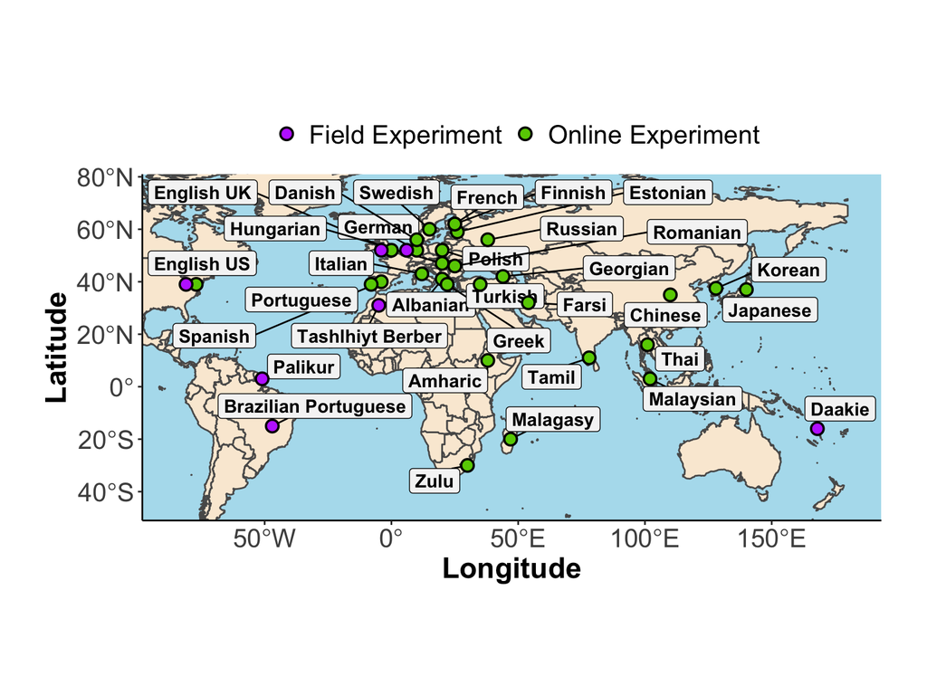

```r
mymap <- ggplot(data = world) +
  geom_sf(fill = 'antiquewhite') +
  geom_label_repel(data = both_info, mapping = aes(x = Longitude, y = Latitude, label = Name),
                  size = 4, point.padding = 0.08, fontface = 'bold',
                  fill = 'grey96') +
  geom_point(data = both_info, mapping = aes(x = Longitude, y = Latitude, fill = `Experiment Type`),
             shape = 21, col = 'black', size = 3, stroke = 1) +
  coord_sf(xlim = c(-85, 180), ylim = c(-45, 75)) +
  scale_fill_manual(values = c(field_color, web_color)) +
  theme_timo +
  theme(legend.position = 'top',
        legend.title = element_blank(),
        panel.background = element_rect(fill = 'lightblue2'))
mymap
```

```r
ggsave(plot = mymap, filename = '../figures/world_map.png', width = 16, height = 8)
```

## Plotting the model estimates, online experiment:

Getting the posteriors per language:

```r
lang_samples <- select(main_samples, contains('Language'))
head(lang_samples)
```

```
##   sd_Language__Intercept r_Language[AL,Intercept] r_Language[AM,Intercept]
## 1              0.3096657               -0.2825830              -0.11646904
## 2              0.2912318               -0.3331729               0.13397877
## 3              0.2573272               -0.2860875              -0.16299683
## 4              0.2539693               -0.3148765              -0.12131018
## 5              0.2767211               -0.3517684               0.02059892
## 6              0.2474216               -0.3868372               0.12060266
##   r_Language[CN,Intercept] r_Language[DE,Intercept]
## 1               -0.4884230                0.3907067
## 2               -0.5041993                0.4264551
## 3               -0.2952462                0.5672372
## 4               -0.3827225                0.5491045
## 5               -0.5529692                0.4405342
## 6               -0.3190924                0.4785781
##   r_Language[DK,Intercept] r_Language[EE,Intercept]
```

[output cut: 69 more lines]

Get rid of the first, which is across all of them:

```r
lang_samples <- lang_samples[, -1]
```

Compute 95% CI for all of these:

```r
lower_CIs <- apply(lang_samples, FUN = function(x) quantile(x, 0.025), MARGIN = 2)
upper_CIs <- apply(lang_samples, FUN = function(x) quantile(x, 0.975), MARGIN = 2)
post_mean <- colMeans(lang_samples)
```

Put those into a table, with logistic transform back to probabilities:

```r
lang_intervals <- tibble(Language = str_extract(colnames(lang_samples), '[A-Z]{2,2}'),
                         lower_CI = plogis(lower_CIs),
                         upper_CI = plogis(upper_CIs),
                         M = plogis(post_mean))
```

Merge with name for plotting:

```r
lang_intervals$Name <- lang_info[match(lang_intervals$Language, lang_info$Language), ]$Name
```

Change “English UK” label to just “English”:

```r
lang_intervals[lang_intervals$Name == 'English UK', ]$Name <- 'English'
```

Change the order of language levels according to the posterior mean:

```r
lang_intervals <- arrange(lang_intervals, M)
lang_intervals <- mutate(lang_intervals,
                         Name = factor(Name, levels = lang_intervals$Name))
```

Make a plot with accuracy per language:

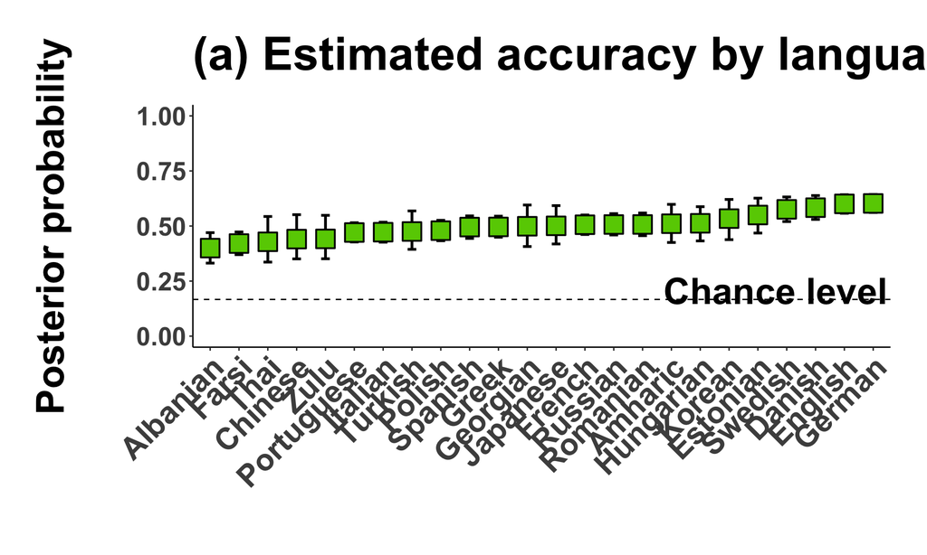

```r
lang_plot <- ggplot(data = lang_intervals,
                    mapping = aes(x = Name, y = M, ymin = lower_CI, ymax = upper_CI)) +
  geom_errorbar(width = 0.3, lwd = 1) +
  geom_point(pch = 22, size = 7, fill = web_color, col = 'black', stroke = 1) +
  geom_hline(yintercept = 1/6, linetype = 2) +
  theme_timo +
  annotate('text', label = 'Chance level', x = 24.5, y = 1/6 + 0.04,
           size = 10, fontface = 'bold', hjust = 1) +
  coord_cartesian(ylim = c(0, 1)) +
  theme(axis.text.x = element_text(angle = 45, hjust = 1, vjust = 1, face = 'bold', size = 24),
        axis.title.y = element_text(margin = margin(t = 0, r = 50, b = 0, l = 0),
                                    size = 30),
        axis.text.y = element_text(face = 'bold', size = 20),
        plot.title = element_text(face = 'bold', size = 36, hjust = 0,
                                  margin = margin(t = 0, r = 0, b = 20, l = 0))) +
  labs(title = '(a) Estimated accuracy by language',
       x = '', y = 'Posterior probability')
lang_plot
```

Getting the posteriors per meaning:

```r
meaning_samples <- select(main_samples, contains('Meaning'))
head(meaning_samples)
```

```
##   sd_Meaning__Intercept r_Meaning[bad,Intercept] r_Meaning[big,Intercept]
## 1             1.1972196               0.15108545              -0.51769789
## 2             1.1270679               0.44131188              -0.26759040
## 3             0.9837413               0.16595819               0.03350526
## 4             1.0177757               0.10013507              -0.03392645
## 5             1.0021516              -0.03858036              -0.30492566
## 6             0.9096452               0.15844783              -0.14925937
##   r_Meaning[child,Intercept] r_Meaning[cook,Intercept]
## 1                   1.111145                -1.0423919
## 2                   1.532748                -1.1018804
## 3                   1.199471                -0.9779907
## 4                   1.229906                -0.8564208
## 5                   1.472501                -0.7371264
## 6                   1.837472                -0.4142564
##   r_Meaning[cut,Intercept] r_Meaning[deer,Intercept]
```

[output cut: 90 more lines]

Get rid of the first, which is across all of them:

```r
meaning_samples <- meaning_samples[, -1]
```

Compute 95% CI for all of these:

```r
lower_CIs <- apply(meaning_samples, FUN = function(x) quantile(x, 0.025), MARGIN = 2)
upper_CIs <- apply(meaning_samples, FUN = function(x) quantile(x, 0.975), MARGIN = 2)
post_mean <- colMeans(meaning_samples)
```

Put those into a table, with logistic transform back to probabilities:

```r
meaning_intervals <- tibble(Meaning = str_extract(colnames(meaning_samples), '\\[[a-z]{2,10}'),
                            lower_CI = plogis(lower_CIs),
                            upper_CI = plogis(upper_CIs),
                            M = plogis(post_mean))
meaning_intervals <- mutate(meaning_intervals,
                            Meaning = str_replace(Meaning, '\\[', ''))
```

Change the order of language levels according to the posterior mean:

```r
meaning_intervals <- arrange(meaning_intervals, M)
meaning_intervals <- mutate(meaning_intervals,
                            Meaning = factor(Meaning, levels = meaning_intervals$Meaning))
```

Make a plot with accuracy per meaning:

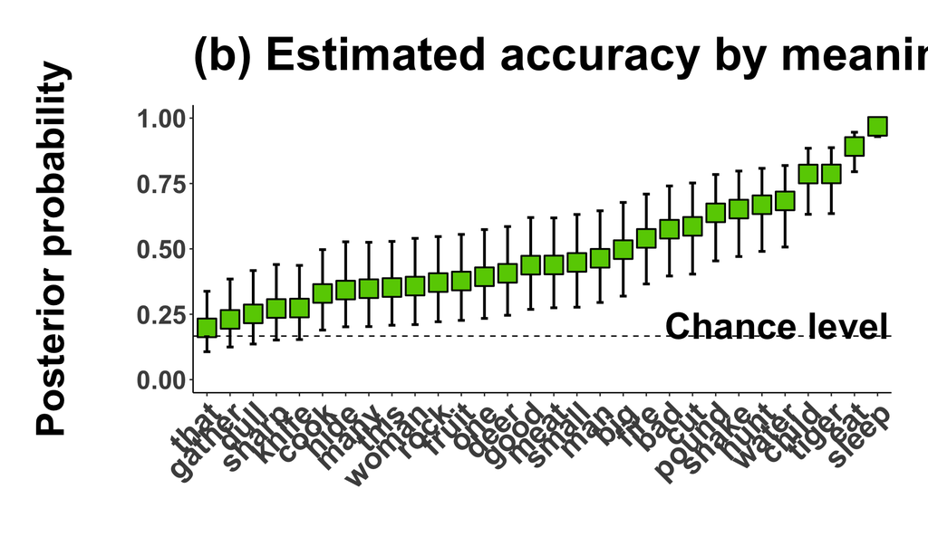

```r
meaning_plot <- ggplot(data = meaning_intervals,
                    mapping = aes(x = Meaning, y = M, ymin = lower_CI, ymax = upper_CI)) +
  geom_errorbar(width = 0.3, lwd = 1) +
  geom_point(pch = 22, size = 7, fill = web_color, col = 'black', stroke = 1) +
  geom_hline(yintercept = 1/6, linetype = 2) +
  theme_timo +
  annotate('text', label = 'Chance level', x = 30.5, y = 1/6 + 0.04,
           size = 10, fontface = 'bold', hjust = 1) +
  coord_cartesian(ylim = c(0, 1)) +
  theme(axis.text.x = element_text(angle = 45, hjust = 1, vjust = 1, face = 'bold', size = 24),
        axis.title.y = element_text(margin = margin(t = 0, r = 50, b = 0, l = 0),
                                    size = 30),
        axis.text.y = element_text(face = 'bold', size = 20),
        plot.title = element_text(face = 'bold', size = 36, hjust = 0,
                                  margin = margin(t = 0, r = 0, b = 20, l = 0))) +
  labs(title = '(b) Estimated accuracy by meaning',
       x = '', y = 'Posterior probability')
meaning_plot
```

Put both together:

[figure not shown]

```r
my_layout <- rbind(c(1, 1, 1, 1, 1, 1, 1, 1, NA),
                   c(1, 1, 1, 1, 1, 1, 1, 1, NA),
                   c(1, 1, 1, 1, 1, 1, 1, 1, NA),
                   c(1, 1, 1, 1, 1, 1, 1, 1, NA),
                   c(1, 1, 1, 1, 1, 1, 1, 1, NA),
                   c(1, 1, 1, 1, 1, 1, 1, 1, NA),
                   c(1, 1, 1, 1, 1, 1, 1, 1, NA),
                   c(1, 1, 1, 1, 1, 1, 1, 1, NA),
                   c(1, 1, 1, 1, 1, 1, 1, 1, NA),
                   c(1, 1, 1, 1, 1, 1, 1, 1, NA),
                   c(NA, NA, NA, NA, NA, NA, NA, NA, NA),
                   c(2, 2, 2, 2, 2, 2, 2, 2, 2),
                   c(2, 2, 2, 2, 2, 2, 2, 2, 2),
                   c(2, 2, 2, 2, 2, 2, 2, 2, 2),
                   c(2, 2, 2, 2, 2, 2, 2, 2, 2),
                   c(2, 2, 2, 2, 2, 2, 2, 2, 2),
                   c(2, 2, 2, 2, 2, 2, 2, 2, 2),
                   c(2, 2, 2, 2, 2, 2, 2, 2, 2),
                   c(2, 2, 2, 2, 2, 2, 2, 2, 2),
                   c(2, 2, 2, 2, 2, 2, 2, 2, 2),
                   c(2, 2, 2, 2, 2, 2, 2, 2, 2))
multi_plot <- grid.arrange(lang_plot, meaning_plot,
                           layout_matrix = my_layout)
```

```r
ggsave(plot = multi_plot, '../figures/web_models.png', width = 24, height = 22)
```

## Field experiment:

Getting the posteriors per language:

```r
field_lang_samples <- select(field_samples, contains('Language'))
head(field_lang_samples)
```

```
##   sd_Language__Intercept r_Language[BE,Intercept] r_Language[BR,Intercept]
## 1              1.1581600                0.6870909                0.6497720
## 2              1.0863762                0.7112788                0.7608046
## 3              0.6400375                0.6391627                0.2914962
## 4              0.6536550                0.2155848                0.1009153
## 5              0.4848766                0.1377019                0.1593974
## 6              1.5615521                0.7620628                0.4852143
##   r_Language[DE,Intercept] r_Language[PA,Intercept]
## 1                1.0453364               -0.2179788
## 2                1.1945131               -0.5370183
## 3                0.7469605               -0.5116131
## 4                0.4904831               -0.8564168
## 5                0.2570058               -0.9352070
## 6                0.9975568               -0.1653195
##   r_Language[SR,Intercept] r_Language[US,Intercept]
## 1               -0.9175117               0.51338706
## 2               -0.7961927               0.48798686
## 3               -0.8106198               0.32547739
## 4               -1.1850278               0.26125337
## 5               -1.0401819              -0.09838896
## 6               -0.7090198               0.79483408
##   r_Language[VA,Intercept]
## 1              -0.02203895
## 2               0.07400811
## 3              -0.53764529
## 4              -0.59478530
## 5              -0.95896741
## 6               0.12636954
```

Get rid of the first, which is across all of them:

```r
field_lang_samples <- field_lang_samples[, -1]
```

Compute 95% CI for all of these:

```r
lower_CIs <- apply(field_lang_samples, FUN = function(x) quantile(x, 0.025), MARGIN = 2)
upper_CIs <- apply(field_lang_samples, FUN = function(x) quantile(x, 0.975), MARGIN = 2)
post_mean <- colMeans(field_lang_samples)
```

Put those into a table, with logistic transform back to probabilities:

```r
field_lang_intervals <- tibble(Language = str_extract(colnames(field_lang_samples), '[A-Z]{2,2}'),
                               lower_CI = plogis(lower_CIs),
                               upper_CI = plogis(upper_CIs),
                               M = plogis(post_mean))
```

Add language names for plotting:

```r
field_lang_intervals$Name <- NA
field_lang_intervals[field_lang_intervals$Language == 'DE', ]$Name <- 'German'
field_lang_intervals[field_lang_intervals$Language == 'US', ]$Name <- 'English (US)'
field_lang_intervals[field_lang_intervals$Language == 'BE', ]$Name <- 'English (UK)'
field_lang_intervals[field_lang_intervals$Language == 'BR', ]$Name <- 'Tashlhiyt Berber'
field_lang_intervals[field_lang_intervals$Language == 'PA', ]$Name <- 'Palikur'
field_lang_intervals[field_lang_intervals$Language == 'VA', ]$Name <- 'Daakie'
field_lang_intervals[field_lang_intervals$Language == 'SR', ]$Name <- 'Brazilian Portuguese'
```

Change the order of language levels according to the posterior mean:

```r
field_lang_intervals <- arrange(field_lang_intervals, M)
field_lang_intervals <- mutate(field_lang_intervals,
                         Name = factor(Name, levels = field_lang_intervals$Name))
```

Make a plot with accuracy per language:

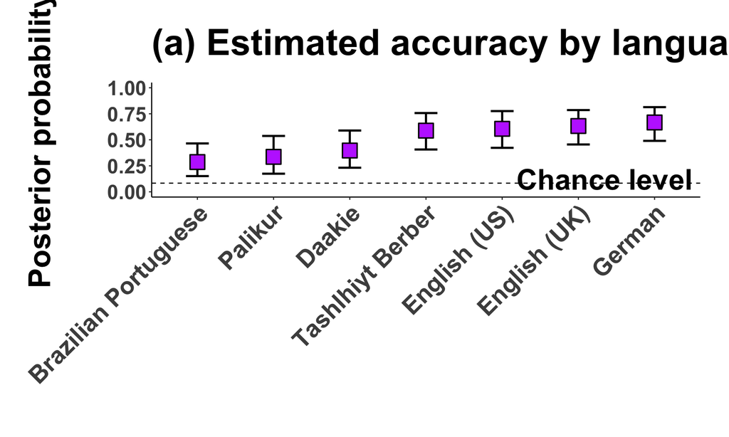

```r
field_lang_plot <- ggplot(data = field_lang_intervals,
                    mapping = aes(x = Name, y = M, ymin = lower_CI, ymax = upper_CI)) +
  geom_errorbar(width = 0.3, lwd = 1) +
  geom_point(pch = 22, size = 7, fill = field_color, col = 'black', stroke = 1) +
  geom_hline(yintercept = 1/12, linetype = 2) +
  theme_timo +
  annotate('text', label = 'Chance level', x = 7.5, y = 1/12 + 0.04,
           size = 10, fontface = 'bold', hjust = 1) +
  coord_cartesian(ylim = c(0, 1)) +
  theme(axis.text.x = element_text(angle = 45, hjust = 1, vjust = 1, face = 'bold', size = 24),
        axis.title.y = element_text(margin = margin(t = 0, r = 50, b = 0, l = 0),
                                    size = 30),
        axis.text.y = element_text(face = 'bold', size = 20),
        plot.title = element_text(face = 'bold', size = 36, hjust = 0,
                                  margin = margin(t = 0, r = 0, b = 20, l = 0))) +
  labs(title = '(a) Estimated accuracy by language',
       x = '', y = 'Posterior probability')
field_lang_plot
```

Getting the posteriors per meaning:

```r
field_meaning_samples <- select(field_samples, contains('Meaning'))
head(field_meaning_samples)
```

```
##   sd_Meaning__Intercept r_Meaning[child,Intercept]
## 1             1.9986969                  2.2509439
## 2             1.1692799                  1.7365104
## 3             0.9037237                  1.1612638
## 4             0.4852634                  0.2976905
## 5             0.4657475                  0.7129759
## 6             1.3191277                  0.9464182
##   r_Meaning[deer,Intercept] r_Meaning[fire,Intercept]
## 1                1.25374245               -0.26332136
## 2                0.73447621               -0.14659941
## 3               -0.38578414               -1.14914632
## 4                0.18414207                0.51335496
## 5               -0.11947247                0.06090939
## 6               -0.04331323               -2.21404806
##   r_Meaning[fruit,Intercept] r_Meaning[knife,Intercept]
```

[output cut: 34 more lines]

Get rid of the first, which is across all of them:

```r
field_meaning_samples <- field_meaning_samples[, -1]
```

Compute 95% CI for all of these:

```r
lower_CIs <- apply(field_meaning_samples, FUN = function(x) quantile(x, 0.025), MARGIN = 2)
upper_CIs <- apply(field_meaning_samples, FUN = function(x) quantile(x, 0.975), MARGIN = 2)
post_mean <- colMeans(field_meaning_samples)
```

Put those into a table, with logistic transform back to probabilities:

```r
field_meaning_intervals <- tibble(Meaning = str_extract(colnames(field_meaning_samples), '\\[[a-z]{2,10}'),
                            lower_CI = plogis(lower_CIs),
                            upper_CI = plogis(upper_CIs),
                            M = plogis(post_mean))
field_meaning_intervals <- mutate(field_meaning_intervals,
                            Meaning = str_replace(Meaning, '\\[', ''))
```

Change the order of language levels according to the posterior mean:

```r
field_meaning_intervals <- arrange(field_meaning_intervals, M)
field_meaning_intervals <- mutate(field_meaning_intervals,
                                  Meaning = factor(Meaning, levels = field_meaning_intervals$Meaning))
```

Make a plot with accuracy per meaning:

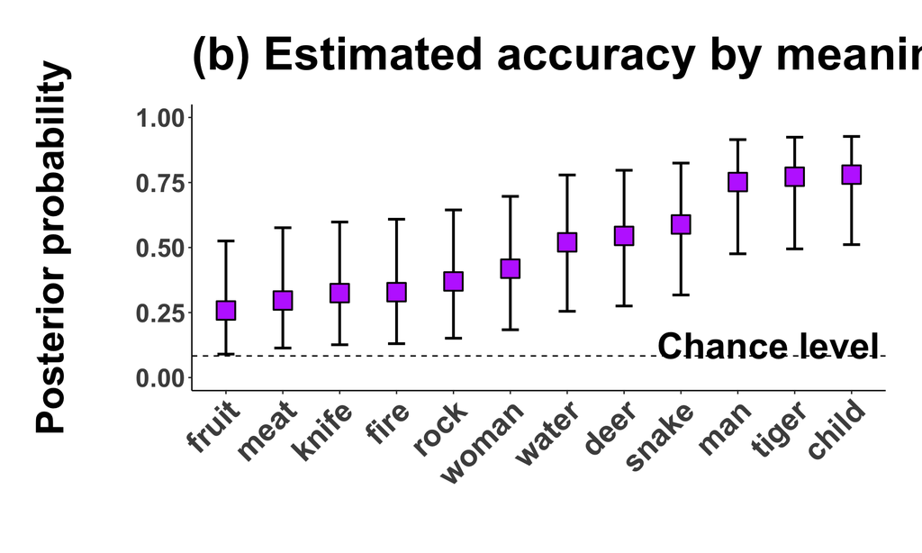

```r
field_meaning_plot <- ggplot(data = field_meaning_intervals,
                    mapping = aes(x = Meaning, y = M, ymin = lower_CI, ymax = upper_CI)) +
  geom_errorbar(width = 0.3, lwd = 1) +
  geom_point(pch = 22, size = 7, fill = field_color, col = 'black', stroke = 1) +
  geom_hline(yintercept = 1/12, linetype = 2) +
  theme_timo +
  annotate('text', label = 'Chance level', x = 12.5, y = 1/12 + 0.04,
           size = 10, fontface = 'bold', hjust = 1) +
  coord_cartesian(ylim = c(0, 1)) +
  theme(axis.text.x = element_text(angle = 45, hjust = 1, vjust = 1, face = 'bold', size = 24),
        axis.title.y = element_text(margin = margin(t = 0, r = 50, b = 0, l = 0),
                                    size = 30),
        axis.text.y = element_text(face = 'bold', size = 20),
        plot.title = element_text(face = 'bold', size = 36, hjust = 0,
                                  margin = margin(t = 0, r = 0, b = 20, l = 0))) +
  labs(title = '(b) Estimated accuracy by meaning',
       x = '', y = 'Posterior probability')
field_meaning_plot
```

Put both together:

[figure not shown]

```r
my_layout <- rbind(c(1, 1, 1, 1, 1, 1, NA, NA, NA),
                   c(1, 1, 1, 1, 1, 1, NA, NA, NA),
                   c(1, 1, 1, 1, 1, 1, NA, NA, NA),
                   c(1, 1, 1, 1, 1, 1, NA, NA, NA),
                   c(1, 1, 1, 1, 1, 1, NA, NA, NA),
                   c(1, 1, 1, 1, 1, 1, NA, NA, NA),
                   c(1, 1, 1, 1, 1, 1, NA, NA, NA),
                   c(1, 1, 1, 1, 1, 1, NA, NA, NA),
                   c(1, 1, 1, 1, 1, 1, NA, NA, NA),
                   c(1, 1, 1, 1, 1, 1, NA, NA, NA),
                   c(NA, NA, NA, NA, NA, NA, NA, NA, NA),
                   c(2, 2, 2, 2, 2, 2, 2, 2, 2),
                   c(2, 2, 2, 2, 2, 2, 2, 2, 2),
                   c(2, 2, 2, 2, 2, 2, 2, 2, 2),
                   c(2, 2, 2, 2, 2, 2, 2, 2, 2),
                   c(2, 2, 2, 2, 2, 2, 2, 2, 2),
                   c(2, 2, 2, 2, 2, 2, 2, 2, 2),
                   c(2, 2, 2, 2, 2, 2, 2, 2, 2),
                   c(2, 2, 2, 2, 2, 2, 2, 2, 2),
                   c(2, 2, 2, 2, 2, 2, 2, 2, 2),
                   c(2, 2, 2, 2, 2, 2, 2, 2, 2))
field_multi_plot <- grid.arrange(field_lang_plot, field_meaning_plot,
                           layout_matrix = my_layout)
```

```r
ggsave(plot = field_multi_plot, '../figures/field_models.png', width = 20, height = 22)
```

This completes this analysis.